# Sismicidad SGC por cuadrante-semana: exposición sísmica a la red eléctrica

Cindy Carolina Lugo Rozo

2026-10-27

# Introducción

Este documento incorpora la **sismicidad** al panel semana x cuadrante de SAIDI/SAIFI, a partir del catálogo del Servicio Geológico Colombiano (SGC), período 2019-01-01 a 2026-08-17.

**Hipótesis:** eventos sísmicos cercanos y de mayor magnitud pueden dañar directamente la infraestructura eléctrica (torres, transformadores, aisladores) o inducir fallas por vibración/asentamiento del terreno, aumentando SAIDI/SAIFI en la semana del evento y posiblemente en las semanas inmediatamente posteriores (daño acumulado, réplicas).

## Paquetes y carga de insumos previos

```r
options(repos = c(CRAN = "https://cloud.r-project.org"))

paquetes_sismos <- c("sf", "dplyr", "lubridate", "tidyr", "ggplot2",
                     "knitr", "kableExtra", "scales", "leaflet", "purrr",
                     "readr", "units")

invisible(lapply(paquetes_sismos, function(p) {
  if (!requireNamespace(p, quietly = TRUE)) install.packages(p)
  library(p, character.only = TRUE)
}))
```

```r
# Misma logica que Scripts/Edwin/analisis_correlacion.Rmd.
# Este Rmd vive en Scripts/Cindy/v4/ → el .env de la raiz esta 3 niveles arriba.
env_path <- file.path("..", "..", "..", ".env")
if (file.exists(".env")) {
  readRenviron(".env")
} else if (file.exists(env_path)) {
  readRenviron(env_path)
}

UBICACION_DATA <- Sys.getenv("UBICACION_DATA")
if (UBICACION_DATA == "") {
  stop("UBICACION_DATA no esta definida. Verifica el archivo .env.")
}

cat(sprintf("UBICACION_DATA: %s\n", UBICACION_DATA))
```

```
## UBICACION_DATA: C:/Users/User/OneDrive - PUJ Cali/Archivos de EDWIN SILVA SALAS - Projecto_Grado_Javeriana/Data_Project
```

```r
DIR_IMAGENES <- file.path(
  UBICACION_DATA, "imagenes", "sismicidad_cuadrantes_reales"
)
dir.create(DIR_IMAGENES, recursive = TRUE, showWarnings = FALSE)
knitr::opts_chunk$set(
  fig.path = paste0(DIR_IMAGENES, "/"),
  dev = "png"
)
```

```r
if (!exists("data_final")) {
  data_final <- readRDS(file.path(UBICACION_DATA, "data_final_modelo_cuadrantes_reales.rds"))
  cat("data_final recargado desde el .rds exportado.\n")
}

if (!exists("centroides_cuadrante_real")) {
  ruta_centroides <- file.path(UBICACION_DATA, "centroides_cuadrantes_reales.csv")
  if (!file.exists(ruta_centroides)) {
    stop("No se encontró centroides_cuadrantes_reales.csv. Corre primero el documento de infraestructura/NDVI.")
  }
  centroides_cuadrante_real <- read_csv(ruta_centroides, show_col_types = FALSE)
  cat("centroides_cuadrante_real recargado desde CSV.\n")
}

data_final <- data_final %>% mutate(id_cuadrante = as.character(id_cuadrante))

centroides_real <- centroides_cuadrante_real %>%
  rename(id_cuadrante = CUADRANTE) %>%
  mutate(id_cuadrante = as.character(id_cuadrante))

cat(sprintf("Cuadrantes con centroide real disponible: %d\n", nrow(centroides_real)))
```

```
## Cuadrantes con centroide real disponible: 344
```

# Parte 1 — Carga y preparación del catálogo sísmico (SGC)

## Carga del catálogo

Ajusta la ruta según dónde hayas guardado la descarga del SGC (GeoJSON, shapefile o `.rds` con el objeto `sf` de puntos).

```r
ruta_sismos     <- file.path(UBICACION_DATA, "sismos_sgc.geojson")
ruta_sismos_rds <- file.path(UBICACION_DATA, "sismos_sgc_cache.rds")

if (!file.exists(ruta_sismos) && !file.exists(ruta_sismos_rds)) {
  stop("No se encontró el catálogo de sismos (.geojson ni .rds en caché).")
}

if (file.exists(ruta_sismos_rds)) {
  # Segunda vez en adelante: carga desde .rds, mucho más rápido que
  # volver a parsear el .geojson completo
  sismos <- readRDS(ruta_sismos_rds)
  cat(sprintf("Catálogo cargado desde caché .rds: %d eventos\n", nrow(sismos)))
} else {
  # Primera vez: parsea el .geojson (lento) y guarda la caché para
  # que las próximas corridas ya no repitan este paso
  cat("Cargando .geojson por primera vez (puede tardar varios minutos)...\n")
  if (!requireNamespace("geojsonsf", quietly = TRUE)) install.packages("geojsonsf")

  sismos <- geojsonsf::geojson_sf(ruta_sismos)
  saveRDS(sismos, ruta_sismos_rds)
  cat(sprintf("Catálogo cargado: %d eventos. Caché guardada en sismos_sgc_cache.rds\n", nrow(sismos)))
}
```

```
## Catálogo cargado desde caché .rds: 787060 eventos
```

```r
str(sismos)
```

```
## Classes 'sf' and 'data.frame':   787060 obs. of  19 variables:
##  $ mag_type       : chr  "MLr_3" "MLr_3" "MLr_1" "MLr_1" ...
##  $ agency         : chr  "SGC" "SGC" "SGC" "SGC" ...
##  $ nst            : chr  "13" "9" "16" "23" ...
##  $ utc_time       : chr  "2026-08-17T20:37:33Z" "2026-08-17T19:13:53Z" "2026-08-17T18:57:41Z" "2026-08-17T18:49:03Z" ...
##  $ place          : chr  "Medina - Cundinamarca, Colombia" "Uribe - Meta, Colombia" "Sipí - Chocó, Colombia" "Sipí - Chocó, Colombia" ...
##  $ latitude_error : chr  "2.302703639939677" "4.2417230507839365" "3.0222706294548898" "3.2272379432378155" ...
##  $ latitude       : num  4.47 3.61 4.59 4.72 6.58 ...
##  $ gap            : chr  "99.0" "123.0" "156.0" "184.0" ...
##  $ magnitude      : num  1.5 1.4 1.9 2.2 1.7 2.5 1.5 1.5 1.7 2.1 ...
##  $ geometry       :sfc_POINT of length 787060; first list element:  'XYZ' num  -73.39 4.47 -20
##  $ magnitude_error: chr  "0.14565512367891503" "0.12537464464788203" "0.1676294989274871" "0.19950082849402448" ...
##  $ rms            : num  0.7 0.6 0.4 0.6 0.6 0.3 0.1 0.2 0.2 0.6 ...
##  $ depth_error    : chr  "4.808636076253304" "11.071114178177687" "5.4741861349689058" "5.7544463934695802" ...
##  $ local_time     : chr  "2026-08-17T15:37:33Z" "2026-08-17T14:13:53Z" "2026-08-17T13:57:41Z" "2026-08-17T13:49:03Z" ...
##  $ status         : chr  "manual" "manual" "manual" "manual" ...
##  $ id             : chr  "SGC2026qemnrw" "SGC2026qejtnw" "SGC2026qejfow" "SGC2026qeiyhf" ...
##  $ longitude      : num  -73.4 -74.5 -76.6 -76.4 -73.4 ...
##  $ longitude_error: chr  "3.5865389320956877" "2.2642430787063268" "3.2135292456068285" "4.0046576890811227" ...
##  $ depth          : num  20 22 38 82 120 130 15 154 149 37 ...
##  - attr(*, "sf_column")= chr "geometry"
```

## Preparar fechas y geometría

`local_time`/`utc_time` se convierten a `POSIXct`. La geometría original es `POINT Z` (X = longitud, Y = latitud, Z = profundidad); como la profundidad ya está disponible en la columna `depth`, se elimina la coordenada Z para trabajar con operaciones espaciales 2D estándar.

```r
sismos <- sismos %>%
  mutate(
    local_time = ymd_hms(local_time),
    utc_time   = ymd_hms(utc_time)
  ) %>%
  st_zm(drop = TRUE)
```

## Filtrar período de estudio

Se conservan los eventos entre el 1 de enero de 2019 y el 17 de agosto de 2026 (fecha de corte de esta extracción). **2026 es un año incompleto** — no debe compararse directamente con años completos sin tener en cuenta la diferente exposición temporal.

```r
sismos_2019_2026 <- sismos %>%
  filter(
    local_time >= ymd_hms("2019-01-01 00:00:00"),
    local_time <= ymd_hms("2026-08-17 23:59:59")
  )

cat(sprintf("Eventos en el período de estudio: %d\n", nrow(sismos_2019_2026)))
```

```
## Eventos en el período de estudio: 389192
```

```r
cat("Rango cubierto:\n")
```

```
## Rango cubierto:
```

```r
print(range(sismos_2019_2026$local_time, na.rm = TRUE))
```

```
## [1] "2019-01-01 00:10:30 UTC" "2026-08-17 15:37:33 UTC"
```

## Identificación preliminar de eventos en Norte de Santander (exploratoria)

Este filtro por texto (`place`) se usa **solo para exploración inicial**. La asignación definitiva y relevante para el modelo se hace más adelante por **distancia real a cada cuadrante**, sin depender de cómo el SGC redactó el campo `place` ni de límites departamentales estrictos — un sismo con epicentro en Santander pero a pocos km de un cuadrante de Norte de Santander sí puede ser relevante para ese cuadrante.

```r
sismos_NS_texto <- sismos_2019_2026 %>%
  filter(grepl("Norte de Santander", place, ignore.case = TRUE))

cat(sprintf("Eventos identificados preliminarmente (texto 'Norte de Santander'): %d\n",
            nrow(sismos_NS_texto)))
```

```
## Eventos identificados preliminarmente (texto 'Norte de Santander'): 7370
```

# Parte 2 — Caracterización exploratoria de la sismicidad

## Resumen general

```r
resumen_sismos <- sismos_NS_texto %>%
  st_drop_geometry() %>%
  summarise(
    n = n(),
    fecha_min = min(local_time, na.rm = TRUE),
    fecha_max = max(local_time, na.rm = TRUE),
    magnitud_min = min(magnitude, na.rm = TRUE),
    magnitud_max = max(magnitude, na.rm = TRUE),
    magnitud_promedio = mean(magnitude, na.rm = TRUE),
    magnitud_mediana = median(magnitude, na.rm = TRUE),
    profundidad_min = min(depth, na.rm = TRUE),
    profundidad_max = max(depth, na.rm = TRUE),
    profundidad_promedio = mean(depth, na.rm = TRUE)
  )

kable(t(resumen_sismos), col.names = "Valor",
      caption = "Resumen general — sismicidad Norte de Santander (filtro exploratorio por texto)") %>%
  kable_styling(bootstrap_options = c("striped"), full_width = FALSE)
```

Resumen general — sismicidad Norte de Santander (filtro exploratorio por texto)

|  | Valor |
| --- | --- |
| n | 7370 |
| fecha_min | 2019-01-01 04:18:34 |
| fecha_max | 2026-08-16 19:43:48 |
| magnitud_min | -0.4 |
| magnitud_max | 4.7 |
| magnitud_promedio | 1.751642 |
| magnitud_mediana | 1.7 |
| profundidad_min | -5 |
| profundidad_max | 285 |
| profundidad_promedio | 90.45183 |

## Tipos de magnitud reportados

El catálogo usa **distintas escalas/tipos de magnitud** (`mag_type`). No se debe asumir que todas son directamente equivalentes a magnitud de momento (Mw) sin justificación metodológica — se conserva `mag_type` como variable de control, sin homogeneizar por ahora.

```r
tabla_tipo_magnitud <- sismos_NS_texto %>%
  st_drop_geometry() %>%
  count(mag_type, sort = TRUE, name = "n_eventos")

kable(tabla_tipo_magnitud, caption = "Distribución de tipos de magnitud reportados") %>%
  kable_styling(bootstrap_options = c("striped", "condensed"), full_width = FALSE)
```

Distribución de tipos de magnitud reportados

| mag_type | n_eventos |
| --- | --- |
| MLr_3 | 5122 |
| MLr_vmm | 2186 |
| MLr_4 | 26 |
| M | 10 |
| MLr | 10 |
| MLr_2 | 8 |
| M_MLr | 4 |
| MLr_1 | 2 |
| Mw(mB) | 2 |

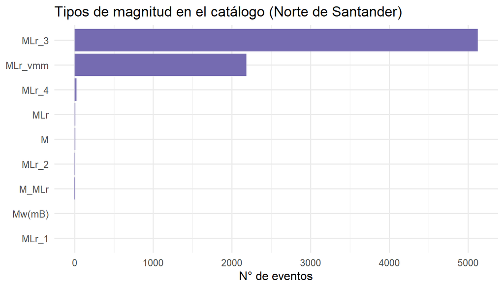

```r
ggplot(tabla_tipo_magnitud, aes(x = reorder(mag_type, n_eventos), y = n_eventos)) +
  geom_col(fill = "#756bb1") +
  coord_flip() +
  labs(title = "Tipos de magnitud en el catálogo (Norte de Santander)",
       x = NULL, y = "N° de eventos") +
  theme_minimal(base_size = 12)
```

## Distribución de la magnitud

```r
summary(sismos_NS_texto$magnitude)
```

```
##    Min. 1st Qu.  Median    Mean 3rd Qu.    Max.
##  -0.400   1.500   1.700   1.752   2.000   4.700
```

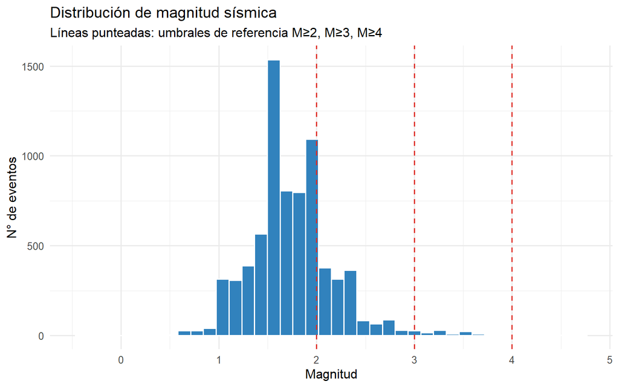

```r
sismos_NS_texto %>%
  st_drop_geometry() %>%
  ggplot(aes(x = magnitude)) +
  geom_histogram(bins = 40, fill = "#3182bd", color = "white") +
  geom_vline(xintercept = c(2, 3, 4), linetype = "dashed", color = "#de2d26") +
  labs(
    title    = "Distribución de magnitud sísmica",
    subtitle = "Líneas punteadas: umbrales de referencia M≥2, M≥3, M≥4",
    x = "Magnitud", y = "N° de eventos"
  ) +
  theme_minimal(base_size = 12)
```

## Sismos por año

**2026 está incompleto** (hasta el 16-17 de agosto) — no comparar directamente su conteo con años completos.

```r
sismos_por_anio <- sismos_NS_texto %>%
  st_drop_geometry() %>%
  mutate(anio = year(local_time)) %>%
  count(anio)

kable(sismos_por_anio, caption = "Número de sismos por año") %>%
  kable_styling(bootstrap_options = c("striped"), full_width = FALSE)
```

Número de sismos por año

| anio | n |
| --- | --- |
| 2019 | 954 |
| 2020 | 796 |
| 2021 | 804 |
| 2022 | 676 |
| 2023 | 888 |
| 2024 | 1246 |
| 2025 | 1106 |
| 2026 | 900 |

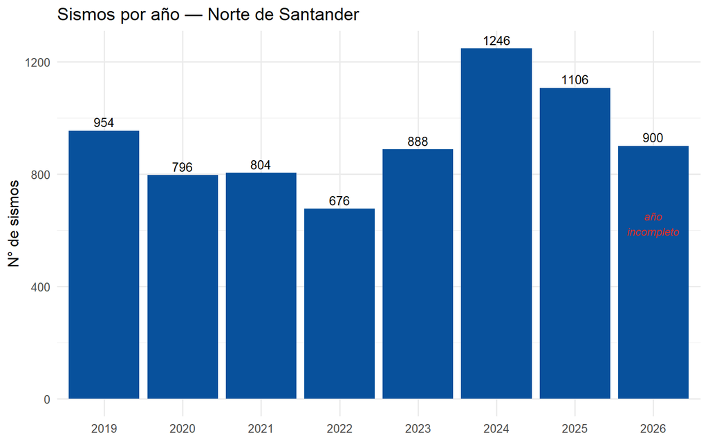

```r
ggplot(sismos_por_anio, aes(x = factor(anio), y = n)) +
  geom_col(fill = "#08519c") +
  geom_text(aes(label = n), vjust = -0.4, size = 3.5) +
  annotate("text", x = as.character(max(sismos_por_anio$anio)),
           y = max(sismos_por_anio$n) * 0.5, label = "año\nincompleto",
           color = "#de2d26", size = 3, fontface = "italic") +
  labs(title = "Sismos por año — Norte de Santander", x = NULL, y = "N° de sismos") +
  theme_minimal(base_size = 12)
```

## Caracterización anual completa

```r
resumen_anual_sismos <- sismos_NS_texto %>%
  st_drop_geometry() %>%
  mutate(anio = year(local_time)) %>%
  group_by(anio) %>%
  summarise(
    n_sismos = n(),
    magnitud_max = max(magnitude, na.rm = TRUE),
    magnitud_promedio = mean(magnitude, na.rm = TRUE),
    magnitud_mediana = median(magnitude, na.rm = TRUE),
    profundidad_promedio = mean(depth, na.rm = TRUE),
    profundidad_min = min(depth, na.rm = TRUE),
    profundidad_max = max(depth, na.rm = TRUE),
    .groups = "drop"
  )

kable(resumen_anual_sismos, digits = 2,
      caption = "Caracterización anual de la sismicidad") %>%
  kable_styling(bootstrap_options = c("striped", "condensed"), full_width = FALSE)
```

Caracterización anual de la sismicidad

| anio | n_sismos | magnitud_max | magnitud_promedio | magnitud_mediana | profundidad_promedio | profundidad_min | profundidad_max |
| --- | --- | --- | --- | --- | --- | --- | --- |
| 2019 | 954 | 4.2 | 1.62 | 1.60 | 91.32 | -2 | 185 |
| 2020 | 796 | 4.5 | 1.82 | 1.80 | 93.44 | -2 | 188 |
| 2021 | 804 | 4.3 | 1.76 | 1.70 | 93.86 | -2 | 183 |
| 2022 | 676 | 4.7 | 1.89 | 1.85 | 84.91 | -2 | 198 |
| 2023 | 888 | 4.0 | 1.80 | 1.80 | 80.95 | -5 | 285 |
| 2024 | 1246 | 4.0 | 1.76 | 1.70 | 87.86 | -1 | 201 |
| 2025 | 1106 | 3.8 | 1.76 | 1.70 | 90.80 | 0 | 190 |
| 2026 | 900 | 3.9 | 1.63 | 1.60 | 100.53 | 0 | 188 |

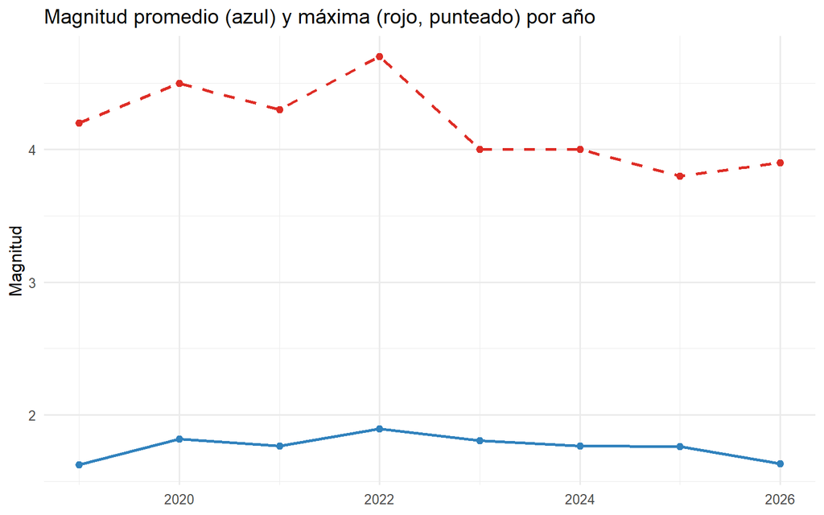

```r
ggplot(resumen_anual_sismos, aes(x = anio)) +
  geom_line(aes(y = magnitud_promedio), color = "#3182bd", linewidth = 1) +
  geom_point(aes(y = magnitud_promedio), color = "#3182bd", size = 2) +
  geom_line(aes(y = magnitud_max), color = "#de2d26", linewidth = 1, linetype = "dashed") +
  geom_point(aes(y = magnitud_max), color = "#de2d26", size = 2) +
  labs(
    title    = "Magnitud promedio (azul) y máxima (rojo, punteado) por año",
    x = NULL, y = "Magnitud"
  ) +
  theme_minimal(base_size = 12)
```

## Conteo por umbral de magnitud

**No se eliminan los sismos pequeños.** Se conservan todos y se construyen medidas alternativas de actividad sísmica a distintos umbrales, dejando que el análisis posterior (econométrico o de aprendizaje automático) determine cuáles tienen mayor capacidad explicativa sobre SAIDI/SAIFI. Los sismos pequeños pueden seguir siendo informativos sobre actividad sísmica local de la zona, más allá del riesgo de daño directo.

```r
resumen_umbrales <- sismos_NS_texto %>%
  st_drop_geometry() %>%
  summarise(
    total    = n(),
    m_ge_2   = sum(magnitude >= 2,   na.rm = TRUE),
    m_ge_3   = sum(magnitude >= 3,   na.rm = TRUE),
    m_ge_4   = sum(magnitude >= 4,   na.rm = TRUE),
    m_ge_4_5 = sum(magnitude >= 4.5, na.rm = TRUE)
  )

kable(t(resumen_umbrales), col.names = "N° eventos",
      caption = "Conteo de sismos por umbral de magnitud") %>%
  kable_styling(bootstrap_options = c("striped"), full_width = FALSE)
```

Conteo de sismos por umbral de magnitud

|  | N° eventos |
| --- | --- |
| total | 7370 |
| m_ge_2 | 1966 |
| m_ge_3 | 138 |
| m_ge_4 | 14 |
| m_ge_4_5 | 4 |

```r
sismos_umbrales_anual <- sismos_NS_texto %>%
  st_drop_geometry() %>%
  mutate(anio = year(local_time)) %>%
  group_by(anio) %>%
  summarise(
    n_sismos     = n(),
    n_m2         = sum(magnitude >= 2, na.rm = TRUE),
    n_m3         = sum(magnitude >= 3, na.rm = TRUE),
    n_m4         = sum(magnitude >= 4, na.rm = TRUE),
    magnitud_max = max(magnitude, na.rm = TRUE),
    .groups = "drop"
  )

kable(sismos_umbrales_anual, caption = "Umbrales de magnitud por año") %>%
  kable_styling(bootstrap_options = c("striped", "condensed"), full_width = FALSE)
```

Umbrales de magnitud por año

| anio | n_sismos | n_m2 | n_m3 | n_m4 | magnitud_max |
| --- | --- | --- | --- | --- | --- |
| 2019 | 954 | 196 | 20 | 2 | 4.2 |
| 2020 | 796 | 238 | 22 | 2 | 4.5 |
| 2021 | 804 | 230 | 18 | 4 | 4.3 |
| 2022 | 676 | 262 | 12 | 2 | 4.7 |
| 2023 | 888 | 284 | 14 | 2 | 4.0 |
| 2024 | 1246 | 310 | 24 | 2 | 4.0 |
| 2025 | 1106 | 300 | 16 | 0 | 3.8 |
| 2026 | 900 | 146 | 12 | 0 | 3.9 |

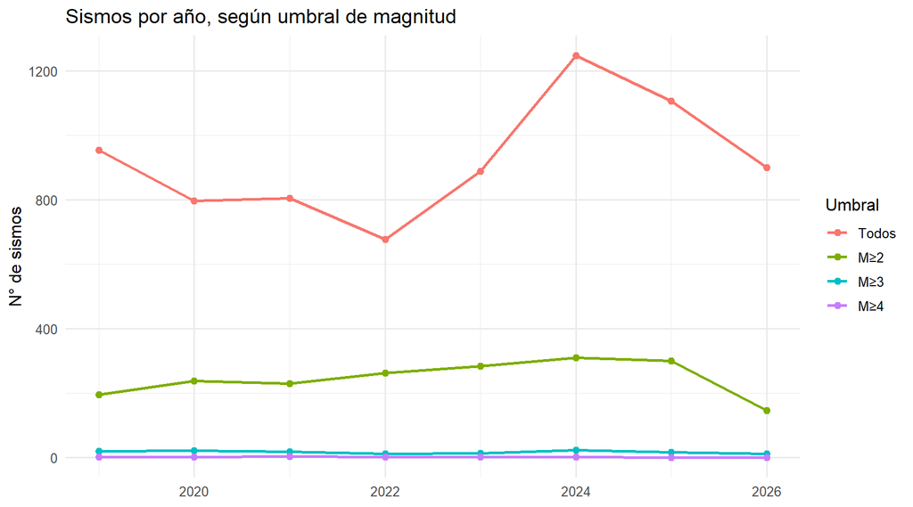

```r
sismos_umbrales_anual %>%
  select(anio, n_sismos, n_m2, n_m3, n_m4) %>%
  pivot_longer(-anio, names_to = "umbral", values_to = "n") %>%
  mutate(umbral = factor(umbral, levels = c("n_sismos", "n_m2", "n_m3", "n_m4"),
                          labels = c("Todos", "M≥2", "M≥3", "M≥4"))) %>%
  ggplot(aes(x = anio, y = n, color = umbral)) +
  geom_line(linewidth = 0.9) +
  geom_point(size = 2) +
  labs(title = "Sismos por año, según umbral de magnitud", x = NULL, y = "N° de sismos", color = "Umbral") +
  theme_minimal(base_size = 12)
```

## Eventos de mayor magnitud (M ≥ 3)

```r
sismos_mayores <- sismos_NS_texto %>%
  st_drop_geometry() %>%
  filter(magnitude >= 3) %>%
  arrange(desc(magnitude)) %>%
  select(id, local_time, place, magnitude, mag_type, depth, latitude, longitude)

kable(head(sismos_mayores, 30), caption = "30 eventos de mayor magnitud (M≥3)") %>%
  kable_styling(bootstrap_options = c("striped", "condensed"), font_size = 10)
```

30 eventos de mayor magnitud (M≥3)

| id | local_time | place | magnitude | mag_type | depth | latitude | longitude |
| --- | --- | --- | --- | --- | --- | --- | --- |
| SGC2022xssict | 2022-12-02 13:09:22 | Cúcuta - Norte de Santander, Colombia | 4.7 | M | 19 | 8.028848 | -72.58665 |
| SGC2022xssict | 2022-12-02 13:09:22 | Cúcuta - Norte de Santander, Colombia | 4.7 | M | 19 | 8.028848 | -72.58665 |
| SGC2020ylfmqs | 2020-12-11 15:07:28 | Villa Caro - Norte de Santander, Colombia | 4.5 | MLr_3 | 184 | 7.867983 | -72.97107 |
| SGC2020ylfmqs | 2020-12-11 15:07:28 | Villa Caro - Norte de Santander, Colombia | 4.5 | MLr_3 | 184 | 7.867983 | -72.97107 |
| SGC2021cawxke | 2021-01-29 09:23:40 | Toledo - Norte de Santander, Colombia | 4.3 | Mw(mB) | 15 | 7.053000 | -72.14483 |
| SGC2021cawxke | 2021-01-29 09:23:40 | Toledo - Norte de Santander, Colombia | 4.3 | Mw(mB) | 15 | 7.053000 | -72.14483 |
| SGC2019aqpsp | 2019-01-09 16:04:23 | Teorama - Norte de Santander, Colombia | 4.2 | MLr_3 | 123 | 8.414000 | -73.32250 |
| SGC2019aqpsp | 2019-01-09 16:04:23 | Teorama - Norte de Santander, Colombia | 4.2 | MLr_3 | 123 | 8.414000 | -73.32250 |
| SGC2024wjsbol | 2024-11-12 11:25:04 | Ábrego - Norte de Santander, Colombia | 4.0 | MLr_3 | 171 | 7.838667 | -73.13433 |
| SGC2023skaujr | 2023-09-18 00:02:54 | Toledo - Norte de Santander, Colombia | 4.0 | MLr_3 | 22 | 7.173193 | -72.25581 |
| SGC2021ebhhyj | 2021-02-26 22:30:19 | La Esperanza - Norte de Santander, Colombia | 4.0 | MLr_vmm | 108 | 7.595000 | -73.48100 |
| SGC2024wjsbol | 2024-11-12 11:25:04 | Ábrego - Norte de Santander, Colombia | 4.0 | MLr_3 | 171 | 7.838667 | -73.13433 |
| SGC2023skaujr | 2023-09-18 00:02:54 | Toledo - Norte de Santander, Colombia | 4.0 | MLr_3 | 22 | 7.173193 | -72.25581 |
| SGC2021ebhhyj | 2021-02-26 22:30:19 | La Esperanza - Norte de Santander, Colombia | 4.0 | MLr_vmm | 108 | 7.595000 | -73.48100 |
| SGC2026frojyr | 2026-03-21 23:11:50 | Cáchira - Norte de Santander, Colombia | 3.9 | MLr_vmm | 135 | 7.628500 | -73.27833 |
| SGC2026frojyr | 2026-03-21 23:11:50 | Cáchira - Norte de Santander, Colombia | 3.9 | MLr_vmm | 135 | 7.628500 | -73.27833 |
| SGC2025solcjv | 2025-09-20 09:31:49 | El Carmen - Norte de Santander, Colombia | 3.8 | MLr_3 | 31 | 8.829833 | -73.40933 |
| SGC2024uzonyg | 2024-10-23 18:57:47 | La Esperanza - Norte de Santander, Colombia | 3.8 | MLr_vmm | 133 | 7.744333 | -73.32217 |
| SGC2024kcjfhv | 2024-05-22 12:10:14 | Teorama - Norte de Santander, Colombia | 3.8 | MLr_3 | 140 | 8.582667 | -73.17500 |
| SGC2025solcjv | 2025-09-20 09:31:49 | El Carmen - Norte de Santander, Colombia | 3.8 | MLr_3 | 31 | 8.829833 | -73.40933 |
| SGC2024uzonyg | 2024-10-23 18:57:47 | La Esperanza - Norte de Santander, Colombia | 3.8 | MLr_vmm | 133 | 7.744333 | -73.32217 |
| SGC2024kcjfhv | 2024-05-22 12:10:14 | Teorama - Norte de Santander, Colombia | 3.8 | MLr_3 | 140 | 8.582667 | -73.17500 |
| SGC2024zlcoix | 2024-12-25 17:35:16 | El Carmen - Norte de Santander, Colombia | 3.7 | MLr_vmm | 122 | 8.543333 | -73.46483 |
| SGC2024zlcoix | 2024-12-25 17:35:16 | El Carmen - Norte de Santander, Colombia | 3.7 | MLr_vmm | 122 | 8.543333 | -73.46483 |
| SGC2025ndcidd | 2025-07-05 09:35:52 | Ábrego - Norte de Santander, Colombia | 3.6 | MLr_3 | 127 | 7.923000 | -73.23533 |
| SGC2025lxjtnd | 2025-06-18 02:57:04 | Salazar - Norte de Santander, Colombia | 3.6 | MLr_3 | 7 | 7.730930 | -72.77741 |
| SGC2020byhfpq | 2020-01-27 23:21:32 | La Esperanza - Norte de Santander, Colombia | 3.6 | MLr_vmm | 124 | 7.701000 | -73.27450 |
| SGC2019ivnyn | 2019-05-06 04:32:27 | Toledo - Norte de Santander, Colombia | 3.6 | MLr_3 | 4 | 7.093833 | -72.23883 |
| SGC2025ndcidd | 2025-07-05 09:35:52 | Ábrego - Norte de Santander, Colombia | 3.6 | MLr_3 | 127 | 7.923000 | -73.23533 |
| SGC2025lxjtnd | 2025-06-18 02:57:04 | Salazar - Norte de Santander, Colombia | 3.6 | MLr_3 | 7 | 7.730930 | -72.77741 |

## Calidad de localización

Variables de calidad disponibles en el catálogo (no se descartan todavía; pueden usarse como filtros de calidad más adelante si el modelo lo requiere).

```r
resumen_calidad <- sismos_NS_texto %>%
  st_drop_geometry() %>%
  summarise(
    rms_mediana                = median(rms, na.rm = TRUE),
    gap_mediana                 = median(gap, na.rm = TRUE),
    nst_mediana                 = median(nst, na.rm = TRUE),
    error_magnitud_mediano       = median(magnitude_error, na.rm = TRUE),
    error_latitud_mediano        = median(latitude_error, na.rm = TRUE),
    error_longitud_mediano       = median(longitude_error, na.rm = TRUE),
    error_profundidad_mediano    = median(depth_error, na.rm = TRUE)
  )

kable(t(resumen_calidad), col.names = "Mediana",
      caption = "Indicadores de calidad de localización (medianas)") %>%
  kable_styling(bootstrap_options = c("striped"), full_width = FALSE)
```

Indicadores de calidad de localización (medianas)

|  | Mediana |
| --- | --- |
| rms_mediana | 0.5 |
| gap_mediana | NA |
| nst_mediana | NA |
| error_magnitud_mediano | NA |
| error_latitud_mediano | NA |
| error_longitud_mediano | NA |
| error_profundidad_mediano | NA |

## Profundidades atípicas (negativas)

Se detectaron profundidades negativas. **No se corrigen arbitrariamente** — pueden corresponder a la convención del catálogo (profundidad relativa a un nivel de referencia) o a incertidumbre de localización.

```r
n_prof_negativa <- sismos_NS_texto %>%
  st_drop_geometry() %>%
  summarise(n_profundidad_negativa = sum(depth < 0, na.rm = TRUE))

cat(sprintf("Eventos con profundidad negativa: %d\n", n_prof_negativa$n_profundidad_negativa))
```

```
## Eventos con profundidad negativa: 58
```

```r
sismos_NS_texto %>%
  st_drop_geometry() %>%
  filter(depth < 0) %>%
  select(id, local_time, place, magnitude, mag_type, depth, depth_error) %>%
  head(20) %>%
  kable(caption = "Eventos con profundidad negativa (muestra)") %>%
  kable_styling(bootstrap_options = c("striped", "condensed"), font_size = 9)
```

Eventos con profundidad negativa (muestra)

| id | local_time | place | magnitude | mag_type | depth | depth_error |
| --- | --- | --- | --- | --- | --- | --- |
| SGC2024jrxvvw | 2024-05-16 19:42:38 | Arboledas - Norte de Santander, Colombia | 1.5 | MLr_3 | -1 | 3.2999999999999998 |
| SGC2023xqrsdx | 2023-12-01 10:41:55 | Salazar - Norte de Santander, Colombia | 1.4 | MLr_3 | -2 | 7.3647997260000002 |
| SGC2023xqnpvw | 2023-12-01 08:38:32 | Mutiscua - Norte de Santander, Colombia | 1.1 | MLr_3 | -2 | 5.8404808380000004 |
| SGC2023ihirdx | 2023-04-27 21:23:30 | Bochalema - Norte de Santander, Colombia | 1.6 | MLr_3 | -1 | 5.2778643010000001 |
| SGC2023gwdaps | 2023-04-07 14:47:51 | Durania - Norte de Santander, Colombia | 1.4 | MLr_3 | -2 | 5.5405132449999996 |
| SGC2023eczsnm | 2023-02-27 20:50:11 | Durania - Norte de Santander, Colombia | 1.2 | MLr_3 | -5 | 6.2557831840000002 |
| SGC2023dzbwgp | 2023-02-25 17:36:58 | Ábrego - Norte de Santander, Colombia | 1.5 | MLr_3 | -1 | 1.2 |
| SGC2022ymgiwm | 2022-12-13 04:37:42 | El Zulia - Norte de Santander, Colombia | 1.7 | MLr_3 | -2 | 9.0355480400000001 |
| SGC2022lieouc | 2022-06-09 20:13:37 | Ábrego - Norte de Santander, Colombia | 1.4 | MLr_3 | -2 | 3.7999999999999998 |
| SGC2022cibgjx | 2022-02-02 07:06:06 | Tibú - Norte de Santander, Colombia | 1.8 | MLr_3 | -1 | 6.0 |
| SGC2021ylpkmn | 2021-12-12 20:06:40 | Herrán - Norte de Santander, Colombia | 1.3 | MLr_3 | -2 | 1.8 |
| SGC2021ppazkw | 2021-08-09 05:42:58 | Ocaña - Norte de Santander, Colombia | 1.1 | MLr_vmm | -1 | 2.1000000000000001 |
| SGC2021hvsgmm | 2021-04-21 13:19:09 | Cáchira - Norte de Santander, Colombia | 2.4 | MLr_vmm | -1 | 2.3999999999999999 |
| SGC2021bxsmwu | 2021-01-27 15:57:20 | Toledo - Norte de Santander, Colombia | 1.9 | MLr_3 | -2 | 3.1000000000000001 |
| SGC2021acdqkc | 2021-01-01 17:58:29 | Toledo - Norte de Santander, Colombia | 2.1 | MLr_3 | -1 | 2.6000000000000001 |
| SGC2020uzlhmu | 2020-10-23 17:19:43 | Ábrego - Norte de Santander, Colombia | 1.2 | MLr_3 | -2 | 4.0 |
| SGC2020uqorzm | 2020-10-18 21:22:12 | Toledo - Norte de Santander, Colombia | 1.7 | MLr_3 | -2 | 6.4000000000000004 |
| SGC2020pwsykt | 2020-08-12 10:15:19 | Toledo - Norte de Santander, Colombia | 2.1 | MLr_3 | -1 | 2.2999999999999998 |
| SGC2020gzxnwd | 2020-04-08 16:20:05 | Mutiscua - Norte de Santander, Colombia | 1.7 | MLr_3 | -1 | 5.0999999999999996 |
| SGC2020esizfv | 2020-03-07 05:36:39 | Toledo - Norte de Santander, Colombia | 3.0 | MLr_3 | -2 | 1.5 |

## Objeto preliminar

Se conserva `sismos_NS` sin depurar (sin eliminar sismos pequeños, profundidades negativas, ni tipos de magnitud) — la depuración se decide después de la caracterización completa, no antes.

```r
sismos_NS <- sismos_NS_texto

cat(sprintf(
  "Número de sismos: %d\nFecha inicial: %s\nFecha final: %s\nMagnitud mínima: %.1f\nMagnitud máxima: %.1f\n",
  nrow(sismos_NS),
  format(min(sismos_NS$local_time, na.rm = TRUE)),
  format(max(sismos_NS$local_time, na.rm = TRUE)),
  min(sismos_NS$magnitude, na.rm = TRUE),
  max(sismos_NS$magnitude, na.rm = TRUE)
))
```

```
## Número de sismos: 7370
## Fecha inicial: 2019-01-01 04:18:34
## Fecha final: 2026-08-16 19:43:48
## Magnitud mínima: -0.4
## Magnitud máxima: 4.7
```

# Parte 3 — Espacialización: distancia real de cada sismo a cada cuadrante

**Cambio metodológico clave respecto a estratificación y UNGRD:** aquí no se asigna por pertenencia municipal. Se calcula la **distancia real** entre el epicentro de cada sismo y el centroide real de cada cuadrante, y se define un **radio de influencia** — un sismo puede ser relevante para un cuadrante aunque su epicentro esté fuera de Norte de Santander, si cae dentro del radio.

Se prueban varios radios (`25`, `50`, `100` km) para no imponer un único criterio arbitrario; el análisis posterior decide cuál aporta mayor capacidad explicativa.

```r
RADIOS_KM <- c(25, 50, 100)

# Todos los sismos del período (no solo el filtro de texto), porque un
# epicentro fuera de Norte de Santander puede seguir estando dentro del
# radio de influencia de un cuadrante cercano al límite departamental.
sismos_geo <- sismos_2019_2026 %>%
  filter(!is.na(latitude), !is.na(longitude)) %>%
  st_transform(4326)

centroides_sf <- centroides_real %>%
  st_as_sf(coords = c("lon", "lat"), crs = 4326, remove = FALSE)

# Matriz de distancias cuadrante x sismo (en metros -> km).
# Con miles de sismos y cientos de cuadrantes esto puede ser una matriz
# grande; se calcula una sola vez y se reutiliza para todos los radios.
matriz_distancias_m <- st_distance(centroides_sf, sismos_geo)
# CORRECCIÓN (27-oct-2026): dividir entre 1000 conserva la unidad "m"; al
# comparar con set_units(radio, "km") el radio se pasaba a metros y todos
# los sismos quedaban dentro de todos los radios. Se trabaja en km numéricos.
matriz_distancias_km <- matrix(as.numeric(matriz_distancias_m) / 1000,
                               nrow = nrow(matriz_distancias_m))

cat(sprintf("Matriz de distancias: %d cuadrantes x %d sismos\n",
            nrow(matriz_distancias_km), ncol(matriz_distancias_km)))
```

```
## Matriz de distancias: 344 cuadrantes x 389192 sismos
```

## Verificación: distribución de la distancia mínima por cuadrante

```r
distancia_min_cuadrante <- apply(matriz_distancias_km, 1, min)

cat(sprintf("Distancia mínima a algún sismo — mediana: %.1f km | máx: %.1f km\n",
            median(distancia_min_cuadrante), max(distancia_min_cuadrante)))
```

```
## Distancia mínima a algún sismo — mediana: 1.3 km | máx: 9.9 km
```

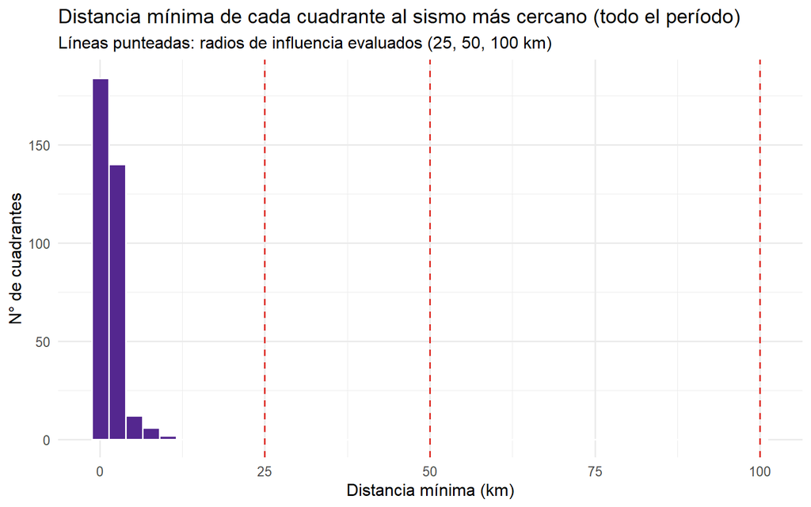

```r
data.frame(id_cuadrante = centroides_real$id_cuadrante,
           dist_min_km  = as.numeric(distancia_min_cuadrante)) %>%
  ggplot(aes(x = dist_min_km)) +
  geom_histogram(bins = 40, fill = "#54278f", color = "white") +
  geom_vline(xintercept = RADIOS_KM, linetype = "dashed", color = "#de2d26") +
  labs(
    title = "Distancia mínima de cada cuadrante al sismo más cercano (todo el período)",
    subtitle = "Líneas punteadas: radios de influencia evaluados (25, 50, 100 km)",
    x = "Distancia mínima (km)", y = "N° de cuadrantes"
  ) +
  theme_minimal(base_size = 12)
```

# Parte 4 — Construcción de variables sísmicas por cuadrante-semana

Para cada cuadrante *i* y semana *t*, dentro de cada radio de influencia *R*, se calculan:

- **`n_sismos`**: número total de sismos dentro del radio, en la semana.
- **`n_sismos_m2` / `n_sismos_m3` / `n_sismos_m4`**: número de sismos con magnitud ≥ 2, ≥ 3, ≥ 4, dentro del radio.
- **`magnitud_max`**: magnitud máxima registrada dentro del radio, en la semana.
- **`dist_sismo_min_km`**: distancia al epicentro más cercano de la semana (independiente del radio, informativo por sí mismo).

```r
semanas_panel <- data_final %>% distinct(semana) %>% arrange(semana)

# Semana del panel a la que pertenece cada sismo (misma lógica de
# "ancla hacia atrás" usada con eventos UNGRD)
# CORRECCIÓN (27-oct-2026): se acota por arriba (última semana + 6 días);
# sin esa cota, los sismos de 2026 se acumulaban en la semana 2025-12-29.
asignar_semana <- function(fecha_evento, semanas) {
  f <- as.Date(fecha_evento)
  if (is.na(f) || f > max(semanas) + 6) return(as.Date(NA))
  candidatas <- semanas[semanas <= f]
  if (length(candidatas) == 0) return(as.Date(NA))
  max(candidatas)
}

sismos_geo <- sismos_geo %>%
  mutate(semana = as.Date(sapply(local_time, asignar_semana, semanas = semanas_panel$semana),
                           origin = "1970-01-01"))

cat(sprintf("Sismos sin semana asignable (fuera del rango del panel): %d\n",
            sum(is.na(sismos_geo$semana))))
```

```
## Sismos sin semana asignable (fuera del rango del panel): 279756
```

```r
# Para cada radio, se construye la tabla cuadrante-semana
construir_variables_sismo <- function(radio_km) {

  # Matriz lógica: TRUE si el sismo j está dentro del radio del cuadrante i
  dentro_radio <- matriz_distancias_km < radio_km

  purrr::map_dfr(seq_len(nrow(centroides_real)), function(i) {

    idx_sismos <- which(dentro_radio[i, ])
    if (length(idx_sismos) == 0) return(NULL)

    sismos_cuadrante <- sismos_geo[idx_sismos, ] %>%
      st_drop_geometry() %>%
      mutate(dist_km = matriz_distancias_km[i, idx_sismos]) %>%
      filter(!is.na(semana))

    if (nrow(sismos_cuadrante) == 0) return(NULL)

    sismos_cuadrante %>%
      group_by(semana) %>%
      summarise(
        n_sismos           = n(),
        n_sismos_m2        = sum(magnitude >= 2, na.rm = TRUE),
        n_sismos_m3        = sum(magnitude >= 3, na.rm = TRUE),
        n_sismos_m4        = sum(magnitude >= 4, na.rm = TRUE),
        magnitud_max       = max(magnitude, na.rm = TRUE),
        dist_sismo_min_km  = min(dist_km, na.rm = TRUE),
        .groups = "drop"
      ) %>%
      mutate(id_cuadrante = centroides_real$id_cuadrante[i])
  })
}

sismos_r25  <- construir_variables_sismo(25)  %>% rename_with(~paste0(., "_r25"),  -c(id_cuadrante, semana))
sismos_r50  <- construir_variables_sismo(50)  %>% rename_with(~paste0(., "_r50"),  -c(id_cuadrante, semana))
sismos_r100 <- construir_variables_sismo(100) %>% rename_with(~paste0(., "_r100"), -c(id_cuadrante, semana))

# CORRECCIÓN (27-oct-2026): dist_sismo_min_km es la distancia al epicentro más
# cercano de la semana, independiente del radio (como se documenta arriba), para
# que no quede NA en las semanas sin sismos dentro del radio.
dist_semana <- purrr::map_dfr(seq_len(nrow(centroides_real)), function(i) {
  tibble(semana = sismos_geo$semana, dist_km = matriz_distancias_km[i, ]) %>%
    filter(!is.na(semana)) %>% group_by(semana) %>%
    summarise(dist_sismo_min_km = min(dist_km), .groups = "drop") %>%
    mutate(id_cuadrante = centroides_real$id_cuadrante[i])
})
for (r in c("_r25", "_r50", "_r100")) {
  obj <- get(paste0("sismos", sub("_", "_", r)))
  obj <- obj %>% select(-any_of(paste0("dist_sismo_min_km", r))) %>%
    full_join(dist_semana %>% rename(!!paste0("dist_sismo_min_km", r) := dist_sismo_min_km),
              by = c("id_cuadrante", "semana"))
  assign(paste0("sismos", r), obj)
}

cat(sprintf("Cuadrante-semanas con actividad — R25: %d | R50: %d | R100: %d\n",
            nrow(sismos_r25), nrow(sismos_r50), nrow(sismos_r100)))
```

```
## Cuadrante-semanas con actividad — R25: 36120 | R50: 36120 | R100: 36120
```

# Parte 5 — Gráficos geográficos y temporales

## Mapa: sismos y cuadrantes reales

```r
if (exists("cuadrantes_infra")) {

  pal_mag <- colorNumeric("YlOrRd", domain = sismos_NS_texto$magnitude)

  leaflet() %>%
    addProviderTiles(providers$CartoDB.Positron) %>%
    addPolygons(
      data = cuadrantes_infra %>% st_transform(4326),
      fillColor = "transparent", color = "gray50", weight = 0.6, opacity = 0.6
    ) %>%
    addCircleMarkers(
      data = sismos_NS_texto %>% st_transform(4326),
      radius = ~pmax(2, magnitude * 2),
      color = ~pal_mag(magnitude),
      stroke = FALSE, fillOpacity = 0.6,
      label = ~paste0("M", magnitude, " — ", format(local_time, "%Y-%m-%d"), " — ", place)
    ) %>%
    addLegend(pal = pal_mag, values = sismos_NS_texto$magnitude,
              title = "Magnitud", position = "bottomright")

} else {
  message("cuadrantes_infra no está en el entorno — se omite el mapa combinado. Se muestra solo los sismos.")

  pal_mag <- colorNumeric("YlOrRd", domain = sismos_NS_texto$magnitude)

  leaflet(sismos_NS_texto %>% st_transform(4326)) %>%
    addProviderTiles(providers$CartoDB.Positron) %>%
    addCircleMarkers(
      radius = ~pmax(2, magnitude * 2), color = ~pal_mag(magnitude),
      stroke = FALSE, fillOpacity = 0.6,
      label = ~paste0("M", magnitude, " — ", format(local_time, "%Y-%m-%d"))
    ) %>%
    addLegend(pal = pal_mag, values = ~magnitude, title = "Magnitud", position = "bottomright")
}
```

[interactive chart not shown]

## Mapa: exposición sísmica acumulada por cuadrante (radio 50 km)

```r
if (exists("cuadrantes_infra")) {

  exposicion_cuadrante <- sismos_r50 %>%
    group_by(id_cuadrante) %>%
    summarise(
      n_sismos_total_r50 = sum(n_sismos_r50),
      magnitud_max_r50   = max(magnitud_max_r50),
      .groups = "drop"
    )

  mapa_exposicion_datos <- cuadrantes_infra %>%
    mutate(id_cuadrante = as.character(if ("id_cuadrante" %in% names(.)) id_cuadrante else CUADRANTE)) %>%
    left_join(exposicion_cuadrante, by = "id_cuadrante") %>%
    st_transform(4326)

  pal_exp <- colorNumeric("Purples", domain = mapa_exposicion_datos$n_sismos_total_r50, na.color = "grey90")

  leaflet(mapa_exposicion_datos) %>%
    addProviderTiles(providers$CartoDB.Positron) %>%
    addPolygons(
      fillColor = ~pal_exp(n_sismos_total_r50),
      fillOpacity = 0.7, color = "gray40", weight = 0.6, opacity = 0.8,
      label = ~paste0("Cuadrante ", id_cuadrante, ": ", n_sismos_total_r50,
                      " sismos históricos dentro de 50 km")
    ) %>%
    addLegend(pal = pal_exp, values = ~n_sismos_total_r50,
              title = "N° sismos\n(radio 50km,\nhistórico)", position = "bottomright")

} else {
  message("cuadrantes_infra no está en el entorno — se omite este mapa.")
}
```

[interactive chart not shown]

## Serie temporal: sismicidad semanal (radio 50 km, agregado)

[figure not shown]

```r
sismos_r50 %>%
  group_by(semana) %>%
  summarise(n_sismos_semana = sum(n_sismos_r50), .groups = "drop") %>%
  ggplot(aes(x = semana, y = n_sismos_semana)) +
  geom_col(fill = "#6a51a3") +
  labs(
    title = "Actividad sísmica semanal (radio 50 km, suma de todos los cuadrantes)",
    x = NULL, y = "N° de sismos"
  ) +
  theme_minimal(base_size = 12)
```

# Parte 6 — Integración al panel

Se une la versión de radio 50 km como variable principal (intermedia entre 25 y 100 km); las otras dos quedan disponibles como variables alternativas para pruebas de sensibilidad del modelo.

```r
data_final <- data_final %>%
  select(-any_of(c(
    "n_sismos_r25", "n_sismos_m2_r25", "n_sismos_m3_r25", "n_sismos_m4_r25", "magnitud_max_r25", "dist_sismo_min_km_r25",
    "n_sismos_r50", "n_sismos_m2_r50", "n_sismos_m3_r50", "n_sismos_m4_r50", "magnitud_max_r50", "dist_sismo_min_km_r50",
    "n_sismos_r100","n_sismos_m2_r100","n_sismos_m3_r100","n_sismos_m4_r100","magnitud_max_r100","dist_sismo_min_km_r100",
    "hubo_sismo"
  ))) %>%
  left_join(sismos_r25,  by = c("id_cuadrante", "semana")) %>%
  left_join(sismos_r50,  by = c("id_cuadrante", "semana")) %>%
  left_join(sismos_r100, by = c("id_cuadrante", "semana")) %>%
  mutate(across(
    c(n_sismos_r25, n_sismos_m2_r25, n_sismos_m3_r25, n_sismos_m4_r25,
      n_sismos_r50, n_sismos_m2_r50, n_sismos_m3_r50, n_sismos_m4_r50,
      n_sismos_r100, n_sismos_m2_r100, n_sismos_m3_r100, n_sismos_m4_r100),
    ~replace_na(., 0)
  )) %>%
  mutate(hubo_sismo_r50 = as.integer(n_sismos_r50 > 0))

cat(sprintf("Panel actualizado: %d filas x %d columnas\n", nrow(data_final), ncol(data_final)))
```

```
## Panel actualizado: 36120 filas x 38 columnas
```

```r
cobertura_sismos <- data_final %>%
  summarise(
    filas_total          = n(),
    semanas_con_sismo_r50 = sum(hubo_sismo_r50),
    pct_semanas_con_sismo  = round(100 * mean(hubo_sismo_r50), 2)
  )

kable(t(cobertura_sismos), col.names = "Valor",
      caption = "Cobertura de sismicidad en el panel (radio 50 km)") %>%
  kable_styling(bootstrap_options = c("striped"), full_width = FALSE)
```

Cobertura de sismicidad en el panel (radio 50 km)

|  | Valor |
| --- | --- |
| filas_total | 36120.0 |
| semanas_con_sismo_r50 | 33158.0 |
| pct_semanas_con_sismo | 91.8 |

## SAIDI/SAIFI según ocurrencia de sismo (radio 50 km)

```r
if (all(c("SAIDI", "SAIFI") %in% names(data_final))) {

  datos_plot <- data_final %>%
    filter(hubo_falla == 1) %>%
    mutate(sismo_f = factor(hubo_sismo_r50, levels = c(0, 1), labels = c("Sin sismo", "Con sismo")))

  if (n_distinct(datos_plot$sismo_f) < 2) {
    message("Solo hay un nivel de sismo_f en las semanas con falla — se omite el gráfico.")
  } else {
    datos_plot %>%
      tidyr::pivot_longer(c(SAIDI, SAIFI), names_to = "indicador", values_to = "valor") %>%
      ggplot(aes(x = sismo_f, y = valor, fill = sismo_f)) +
      geom_boxplot(outlier.alpha = 0.2, width = 0.5) +
      facet_wrap(~indicador, scales = "free_y") +
      scale_fill_manual(values = c("Sin sismo" = "#a1d99b", "Con sismo" = "#54278f")) +
      labs(
        title = "SAIDI/SAIFI según ocurrencia de sismo (radio 50 km)",
        subtitle = "Solo semanas con falla eléctrica registrada",
        x = NULL, y = "Valor"
      ) +
      theme_minimal(base_size = 12) +
      theme(legend.position = "none")
  }

} else {
  message("SAIDI/SAIFI no están en data_final todavía — se omite este gráfico.")
}
```